# R Notebook

model4-4_kai.stanを実行するRファイル

````r
```r
library(rstan)
library(ggplot2)
````

````
```r
```r
fit = stan(\model4-4_kai.stan\, data = data1, seed=1234) # stan実行
````

````
```r
```r
ms = rstan::extract(fit) # MCMCサンプルを抽出
````

````
```r
```r
fit
````

Inference for Stan model: model4-4_kai. 4 chains, each with iter=2000; warmup=1000; thin=1; post-warmup draws per chain=1000, total post-warmup draws=4000.

```
              mean se_mean    sd    2.5%     25%     50%     75%   97.5% n_eff Rhat
```

a -122.29 2.19 74.79 -266.68 -171.35 -122.22 -72.70 24.31 1169 1.00 b 21.96 0.05 1.65 18.67 20.87 21.97 23.07 25.21 1175 1.00 sigma 85.52 0.44 15.71 60.73 74.53 83.41 94.46 122.32 1287 1.01 y_base[1] 404.86 1.05 37.87 330.97 380.28 405.53 428.83 477.92 1295 1.00 y_base[2] 404.86 1.05 37.87 330.97 380.28 405.53 428.83 477.92 1295 1.00 y_base[3] 448.79 0.96 35.07 379.74 426.00 449.20 470.68 516.36 1334 1.00 y_base[4] 580.57 0.69 27.36 525.88 563.21 581.15 597.79 633.01 1569 1.00 y_base[5] 602.54 0.65 26.22 550.15 586.14 603.38 619.18 653.04 1638 1.00 y_base[6] 646.47 0.56 24.12 598.34 631.24 647.31 661.80 692.81 1828 1.00 y_base[7] 712.36 0.45 21.55 669.35 698.92 712.65 725.89 753.85 2304 1.00 y_base[8] 756.29 0.38 20.33 715.52 743.89 756.28 769.19 795.43 2814 1.00 y_base[9] 756.29 0.38 20.33 715.52 743.89 756.28 769.19 795.43 2814 1.00 y_base[10] 822.18 0.31 19.45 783.19 810.17 822.07 834.55 860.11 3852 1.00 y_base[11] 822.18 0.31 19.45 783.19 810.17 822.07 834.55 860.11 3852 1.00 y_base[12] 844.15 0.30 19.43 805.80 831.97 843.97 856.61 882.41 4183 1.00 y_base[13] 932.00 0.34 20.71 891.59 918.95 932.10 944.76 973.08 3804 1.00 y_base[14] 1019.86 0.46 23.84 971.88 1004.48 1019.97 1034.63 1067.67 2726 1.00 y_base[15] 1107.72 0.61 28.20 1052.46 1089.56 1107.73 1125.22 1164.06 2108 1.00 y_base[16] 1107.72 0.61 28.20 1052.46 1089.56 1107.73 1125.22 1164.06 2108 1.00 y_base[17] 1129.68 0.66 29.42 1072.42 1110.72 1129.60 1147.75 1188.30 2009 1.00 y_base[18] 1151.65 0.70 30.68 1091.49 1131.96 1151.55 1170.50 1212.52 1924 1.00 y_base[19] 1173.61 0.74 31.98 1110.77 1152.96 1173.65 1193.34 1236.93 1851 1.00 y_base[20] 1173.61 0.74 31.98 1110.77 1152.96 1173.65 1193.34 1236.93 1851 1.00 y_base_new[1] 382.89 1.10 39.30 305.65 357.35 383.51 407.89 458.70 1280 1.00 y_base_new[2] 404.86 1.05 37.87 330.97 380.28 405.53 428.83 477.92 1295 1.00 y_base_new[3] 426.82 1.01 36.46 355.67 403.11 427.15 449.80 497.26 1313 1.00 y_base_new[4] 448.79 0.96 35.07 379.74 426.00 449.20 470.68 516.36 1334 1.00 y_base_new[5] 470.75 0.91 33.70 404.40 448.82 471.09 491.83 535.51 1359 1.00 y_base_new[6] 492.72 0.87 32.37 428.95 471.83 493.09 513.02 554.89 1388 1.00 y_base_new[7] 514.68 0.82 31.06 452.94 494.71 515.12 534.11 574.19 1422 1.00 y_base_new[8] 536.64 0.78 29.78 477.06 517.44 537.14 555.37 593.34 1462 1.00 y_base_new[9] 558.61 0.73 28.55 501.01 540.36 559.01 576.65 612.74 1510 1.00 y_base_new[10] 580.57 0.69 27.36 525.88 563.21 581.15 597.79 633.01 1569 1.00 y_base_new[11] 602.54 0.65 26.22 550.15 586.14 603.38 619.18 653.04 1638 1.00 y_base_new[12] 624.50 0.61 25.14 574.39 608.90 625.43 640.49 672.86 1725 1.00 y_base_new[13] 646.47 0.56 24.12 598.34 631.24 647.31 661.80 692.81 1828 1.00 y_base_new[14] 668.43 0.52 23.18 622.30 653.89 669.05 683.13 713.12 1956 1.00 y_base_new[15] 690.39 0.49 22.32 645.75 676.51 690.94 704.52 733.12 2112 1.00 y_base_new[16] 712.36 0.45 21.55 669.35 698.92 712.65 725.89 753.85 2304 1.00 y_base_new[17] 734.32 0.41 20.89 692.76 721.40 734.51 747.51 774.27 2537 1.00 y_base_new[18] 756.29 0.38 20.33 715.52 743.89 756.28 769.19 795.43 2814 1.00 y_base_new[19] 778.25 0.36 19.91 738.38 766.02 778.11 790.94 816.70 3130 1.00 y_base_new[20] 800.22 0.33 19.61 761.04 788.12 800.12 812.78 838.26 3479 1.00 y_base_new[21] 822.18 0.31 19.45 783.19 810.17 822.07 834.55 860.11 3852 1.00 y_base_new[22] 844.15 0.30 19.43 805.80 831.97 843.97 856.61 882.41 4183 1.00 y_base_new[23] 866.11 0.30 19.55 827.93 853.82 865.93 878.45 904.87 4351 1.00 y_base_new[24] 888.07 0.30 19.81 849.30 875.59 888.04 900.52 927.68 4310 1.00 y_base_new[25] 910.04 0.32 20.20 870.49 897.45 910.09 922.64 950.99 4089 1.00 y_base_new[26] 932.00 0.34 20.71 891.59 918.95 932.10 944.76 973.08 3804 1.00 y_base_new[27] 953.97 0.36 21.34 912.08 940.30 954.07 967.13 995.80 3491 1.00 y_base_new[28] 975.93 0.39 22.08 932.25 961.78 976.01 989.63 1019.52 3212 1.00 y_base_new[29] 997.90 0.42 22.92 951.92 983.34 997.80 1012.02 1043.35 2954 1.00 y_base_new[30] 1019.86 0.46 23.84 971.88 1004.48 1019.97 1034.63 1067.67 2726 1.00 y_base_new[31] 1041.82 0.49 24.83 992.75 1025.76 1041.95 1057.22 1091.72 2531 1.00 y_base_new[32] 1063.79 0.53 25.90 1012.61 1047.13 1063.90 1079.90 1115.54 2366 1.00 y_base_new[33] 1085.75 0.57 27.02 1032.45 1068.31 1085.85 1102.47 1139.79 2226 1.00 y_base_new[34] 1107.72 0.61 28.20 1052.46 1089.56 1107.73 1125.22 1164.06 2108 1.00 y_base_new[35] 1129.68 0.66 29.42 1072.42 1110.72 1129.60 1147.75 1188.30 2009 1.00 y_base_new[36] 1151.65 0.70 30.68 1091.49 1131.96 1151.55 1170.50 1212.52 1924 1.00 y_base_new[37] 1173.61 0.74 31.98 1110.77 1152.96 1173.65 1193.34 1236.93 1851 1.00 y_base_new[38] 1195.58 0.79 33.31 1129.93 1174.04 1195.85 1216.48 1261.94 1788 1.00 y_new[1] 382.87 1.71 96.00 197.16 319.63 380.23 446.12 574.76 3166 1.00 y_new[2] 405.38 1.88 95.46 211.43 342.85 405.98 468.82 593.10 2565 1.00 y_new[3] 425.80 1.66 93.75 243.78 364.33 424.33 487.33 615.17 3190 1.00 y_new[4] 447.81 1.65 92.98 263.24 389.16 448.21 508.72 627.21 3173 1.00 y_new[5] 472.71 1.61 92.61 292.21 412.68 472.47 532.50 655.20 3307 1.00 y_new[6] 494.69 1.59 92.21 311.55 436.08 492.46 553.60 680.34 3367 1.00 y_new[7] 515.98 1.55 92.10 335.91 455.80 515.15 573.35 699.09 3537 1.00 y_new[8] 536.81 1.67 93.16 352.62 476.66 537.26 597.39 724.96 3115 1.00 y_new[9] 560.85 1.59 93.63 376.20 500.27 561.80 619.28 749.24 3447 1.00 y_new[10] 579.00 1.49 91.50 399.04 520.42 579.79 638.41 758.97 3782 1.00 y_new[11] 604.42 1.43 90.75 421.88 543.90 602.89 663.78 786.58 4039 1.00 y_new[12] 623.60 1.49 89.39 445.50 567.77 624.69 680.21 800.38 3581 1.00 y_new[13] 647.09 1.47 90.48 471.47 588.64 645.28 704.85 827.42 3767 1.00 y_new[14] 666.91 1.48 91.07 486.95 608.04 666.99 726.13 850.40 3783 1.00 y_new[15] 691.03 1.49 89.72 512.22 633.62 690.49 750.21 861.33 3642 1.00 y_new[16] 713.41 1.45 89.22 539.03 656.19 711.16 771.75 891.20 3772 1.00 y_new[17] 735.54 1.51 87.29 563.27 678.55 736.83 792.07 909.00 3357 1.00 y_new[18] 755.62 1.44 89.89 580.68 696.97 757.00 814.55 931.29 3904 1.00 y_new[19] 776.28 1.40 88.06 598.82 718.42 778.42 833.18 946.58 3946 1.00 y_new[20] 801.63 1.42 90.55 624.04 741.63 798.73 861.87 983.90 4053 1.00 y_new[21] 822.72 1.41 88.78 646.85 766.52 822.40 880.41 996.31 3983 1.00 y_new[22] 844.65 1.42 89.39 664.08 786.61 847.24 902.49 1018.88 3963 1.00 y_new[23] 865.18 1.36 88.09 695.03 807.53 864.60 922.38 1039.03 4191 1.00 y_new[24] 888.77 1.40 88.69 715.67 830.34 887.51 945.01 1067.24 4019 1.00 y_new[25] 909.40 1.43 90.13 728.51 851.24 910.40 969.15 1086.68 3958 1.00 y_new[26] 933.89 1.39 87.20 762.73 876.60 935.11 990.04 1109.99 3908 1.00 y_new[27] 952.53 1.42 90.77 772.90 893.23 952.58 1011.13 1136.09 4080 1.00 y_new[28] 974.46 1.40 89.82 796.10 916.04 975.28 1032.77 1152.57 4094 1.00 y_new[29] 994.44 1.47 89.99 810.19 936.75 996.72 1051.57 1166.88 3724 1.00 y_new[30] 1018.69 1.44 91.91 835.28 959.37 1018.95 1077.87 1202.90 4069 1.00 y_new[31] 1041.35 1.52 91.03 861.89 983.49 1040.64 1100.92 1219.96 3601 1.00 y_new[32] 1062.41 1.52 91.52 883.56 1004.48 1060.61 1120.18 1245.81 3623 1.00 y_new[33] 1085.23 1.49 90.44 906.87 1025.88 1083.08 1145.86 1262.93 3671 1.00 y_new[34] 1106.86 1.48 90.04 921.96 1049.95 1107.54 1165.65 1283.75 3713 1.00 y_new[35] 1130.62 1.50 93.34 943.16 1071.84 1130.39 1191.37 1318.85 3873 1.00 y_new[36] 1150.17 1.52 93.47 967.63 1091.43 1149.41 1209.54 1343.00 3786 1.00 y_new[37] 1175.71 1.50 92.01 995.11 1115.64 1174.28 1236.48 1362.55 3755 1.00 y_new[38] 1198.13 1.63 93.01 1012.07 1139.95 1199.86 1256.82 1381.56 3249 1.00 lp__ -93.67 0.05 1.34 -97.20 -94.30 -93.31 -92.66 -92.15 885 1.01

Samples were drawn using NUTS(diag_e) at Thu Dec 24 15:19:15 2020. For each parameter, n_eff is a crude measure of effective sample size, and Rhat is the potential scale reduction factor on split chains (at convergence, Rhat=1).

````
上が一通りの結果
例えばms$y_new[i,j]は、i番目のサンプルにおけるj+22歳の年収の予測値
ms$y_new[,j]とするとj+22歳のサンプル全て
ms$y_new[i,]とするとi番目のサンプルでの各年齢の年収

```r
```r
for (i in 1:length(ms$a)){
  plot(ms$y_new[i,], ann=FALSE, ylim=c(0,1700))
  par(new=T)
}
````

```

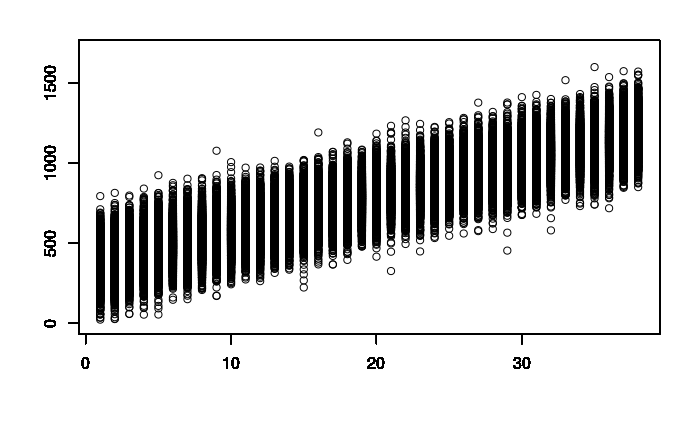

上のグラフは各年齢23~60歳の年収のMCMCサンプル